# Example 19: Tree Models

## Decision Trees

The DecisionTreeClassifier in Sci-Kit Learn is a tree-based learning algorithm used for classification tasks. It works by recursively splitting the dataset into smaller and smaller subsets based on the values of input features. Here's how it works:

1. **Data Splitting**: The algorithm starts with the entire dataset, which contains a set of features (attributes) and their corresponding labels (also called target classes). It selects a feature and a threshold value to split the data into two subsets: one where the feature's value is less than or equal to the threshold and another where it's greater.
2. **Decision Tree**: This splitting process creates a "node" in a tree-like structure called a decision tree. Each node represents a decision point based on a feature and threshold.
3. **Recursive Splitting**: The algorithm continues to split the data at each node into smaller subsets using different features and thresholds. It does this recursively until certain stopping conditions are met, such as reaching a maximum tree depth or having too few data points in a node.
4. **Leaf Nodes**: The final nodes in the tree, called "leaf nodes" or "terminal nodes," contain the predicted class labels. When a new data point reaches a leaf node during prediction, it is assigned the majority class of the training examples in that leaf node.

In summary, the DecisionTreeClassifier creates a decision tree structure by repeatedly splitting the data into subsets based on feature values. It learns how to make decisions by choosing the most informative features and thresholds during training. This tree can then be used to classify new data points by traversing the tree and reaching a leaf node with the predicted class label.

```python
# Standard imports
import numpy as np
import matplotlib.pyplot as plt
import seaborn as sns

# Dataset
from sklearn.datasets import load_iris

# For model and evaluation
from sklearn.tree import DecisionTreeClassifier, plot_tree
from sklearn.ensemble import RandomForestClassifier
from sklearn.model_selection import train_test_split
from sklearn.metrics import accuracy_score, classification_report, confusion_matrix

# For graphing
from matplotlib.colors import ListedColormap
```

For this example, we use the Iris dataset, which we have seen before. While this dataset has 4 features, we will reduce the number of features to 2 so we can better graph our results. This also makes the classification harder because we need all four features to capture the classification relationship.

```python
# Load the Iris dataset
data = load_iris()
X = data.data
y = data.target
X = X[:,0:2] # reduce the dimension to 2D so we can graph it and the classification problem is harder

# Split the data into training, validation, and testing sets
X_train, X_temp, y_train, y_temp = train_test_split(X, y, test_size=0.4, random_state=19)
X_val, X_test, y_val, y_test = train_test_split(X_temp, y_temp, test_size=0.5, random_state=19)

# For fitting the function once hyperparameters are selected
X_train_val = np.concatenate((X_train, X_val))
y_train_val = np.concatenate((y_train, y_val))
```

The process of implementing a decision tree classifier follows the standard format in Sci-Kit Learn. The hyperparameter that we will need to tune is the maximum depth of the tree model. For now, we simply provide some code to tinker with before searching for an optimal depth.

Notice that we offer a classification report at the end--an alternative to the confusion matrix, which contains information about precision, recall, and accuracy (all broken down by category).

```python
# Create a decision tree classifier
dt_classifier = DecisionTreeClassifier(random_state=19, max_depth = 4)

# Fit the classifier to the training data
dt_classifier.fit(X_train, y_train)

# Make predictions on the validation data
y_pred = dt_classifier.predict(X_val)

# Classification report contains accuracy, precision, and recall
report = classification_report(y_val, y_pred, target_names=data.target_names)
print("Classification Report:\n", report)
```

```
Classification Report:
               precision    recall  f1-score   support

      setosa       1.00      0.92      0.96        12
  versicolor       0.57      0.89      0.70         9
   virginica       0.80      0.44      0.57         9

    accuracy                           0.77        30
   macro avg       0.79      0.75      0.74        30
weighted avg       0.81      0.77      0.76        30
```

We still can comput a confusion matrix, which also offers a compelling visual description of the classification.

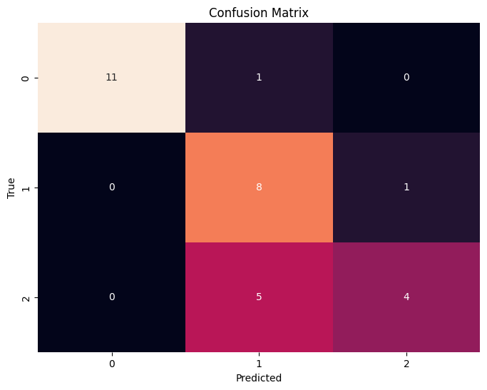

```python
# Calculate the confusion matrix
cm = confusion_matrix(y_val, y_pred)

# Create a figure for the confusion matrix heatmap
plt.figure(figsize=(8, 6))

# Use Seaborn's heatmap to create a full-color confusion matrix
sns.heatmap(cm, annot=True, fmt='d', cbar=False)

# Add labels and title
plt.xlabel('Predicted')
plt.ylabel('True')
plt.title('Confusion Matrix')

# Display the plot
plt.show()
```

Finally, we present a way to visualize the classification by actually depicting the thresholds and branching points discussed at the top of this page.

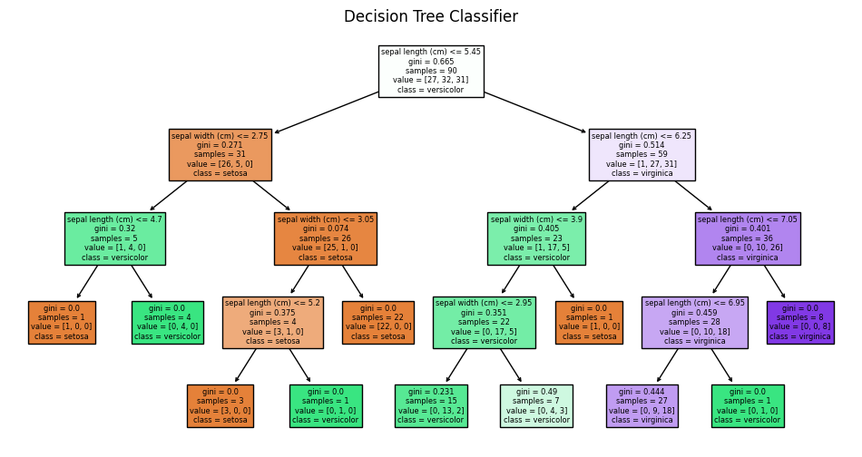

```python
# Visualize the decision tree
plt.figure(figsize=(12, 6))
plot_tree(dt_classifier, filled=True, feature_names=data.feature_names, class_names=data.target_names)
plt.title("Decision Tree Classifier")
plt.show()
```

When the number of features is only 2, we can provide a visualization of the classification.

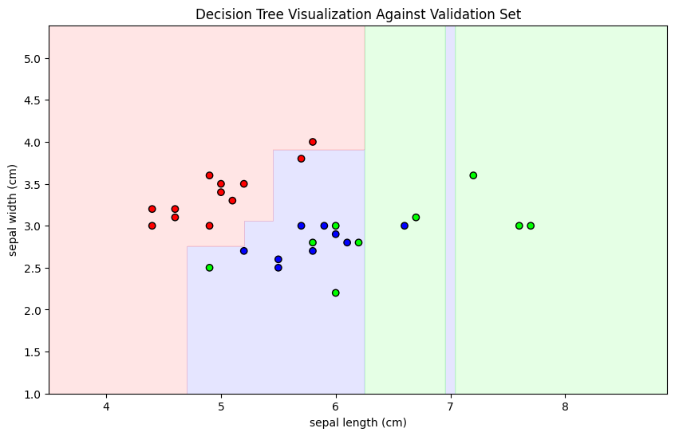

```python
# Create a meshgrid for the decision boundary plot that covers features
x_min, x_max = X_train[:, 0].min() - 1, X_train[:, 0].max() + 1
y_min, y_max = X_train[:, 1].min() - 1, X_train[:, 1].max() + 1
xx, yy = np.meshgrid(np.arange(x_min, x_max, 0.01),
                     np.arange(y_min, y_max, 0.01))

# Predict the class labels for the corresponding meshgrid points using features
mesh_points = np.c_[xx.ravel(), yy.ravel()]
Z = dt_classifier.predict(mesh_points)
Z = Z.reshape(xx.shape)

# Create a color map for the plot
cmap_background = ListedColormap(['#FFAAAA', '#AAAAFF', '#AAFFAA'])
cmap_points = ListedColormap(['#FF0000', '#0000FF', '#00FF00'])

# Plot the decision boundary
plt.figure(figsize=(10, 6))
plt.contourf(xx, yy, Z, cmap=cmap_background, alpha=0.3)
plt.scatter(X_val[:, 0], X_val[:, 1], c=y_val, cmap=cmap_points, marker='o', edgecolor='k')

# Set axis labels and title
plt.xlabel(data.feature_names[0])
plt.ylabel(data.feature_names[1])
plt.title('Decision Tree Visualization Against Validation Set')

plt.show()
```

Now let us use the validation set to discover the optimal model depth using accuracy.

```python
depths = list(range(1, 20))
accuracies = []

for depth in depths:
    # Create a decision tree classifier
    clf = DecisionTreeClassifier(random_state=20, max_depth = depth)

    # Fit the classifier to the training data
    clf.fit(X_train, y_train)

    # Make predictions on the validation data
    y_pred = clf.predict(X_val)

    accuracies.append(accuracy_score(y_pred, y_val))

best_depth = depths[np.argmax(accuracies)]
print(f"Best depth based on validation accuracy: {best_depth}")
```

```
Best depth based on validation accuracy: 3
```

Although this isn't necessary, we can also plot this search visually to see how the changes in depth affect the accuracy.

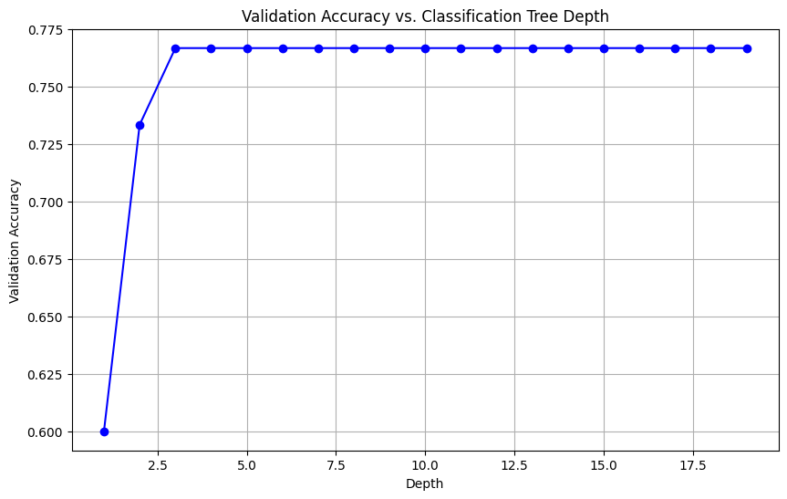

```python
# Plot lambda values vs. validation set metrics
plt.figure(figsize=(10, 6))
plt.plot(depths, accuracies, marker='o', linestyle='-', color='blue')
plt.title('Validation Accuracy vs. Classification Tree Depth')
plt.xlabel('Depth')
plt.ylabel('Validation Accuracy')
plt.grid(True)
```

Now that we know the optimal depth according to the validation set, we can compute the full model and evaluate it against the testing set. Below are all the visualizations to help us understand the classification and how well it performs.

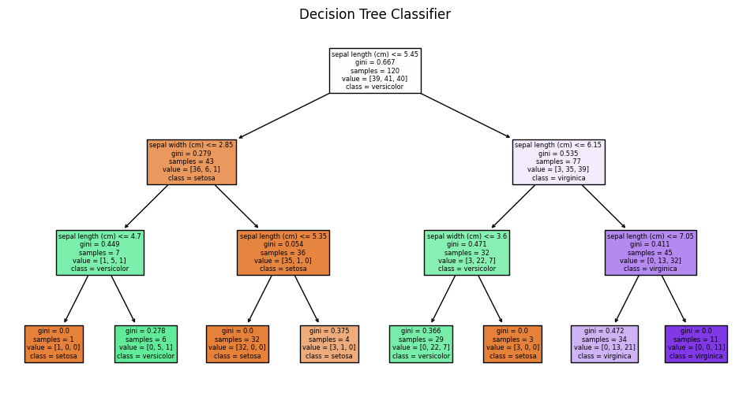

```python
# Create the final decision tree classifier model
dt_classifier = DecisionTreeClassifier(random_state=20, max_depth = best_depth)

# Fit the classifier to the training data
dt_classifier.fit(X_train_val, y_train_val)

# Make predictions on the test data
y_pred = dt_classifier.predict(X_test)

# Visualize the decision tree
plt.figure(figsize=(12, 6))
plot_tree(dt_classifier, filled=True, feature_names=data.feature_names, class_names=data.target_names)
plt.title("Decision Tree Classifier")
plt.show()
```

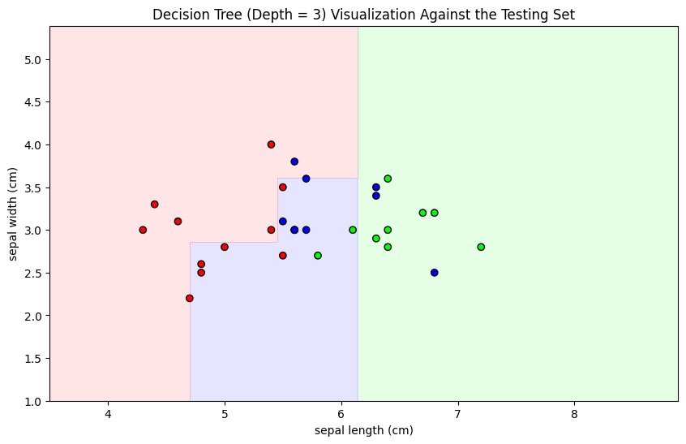

```python
# Create a meshgrid for the decision boundary plot that covers features
x_min, x_max = X_train[:, 0].min() - 1, X_train[:, 0].max() + 1
y_min, y_max = X_train[:, 1].min() - 1, X_train[:, 1].max() + 1
xx, yy = np.meshgrid(np.arange(x_min, x_max, 0.01),
                     np.arange(y_min, y_max, 0.01))

# Predict the class labels for the corresponding meshgrid points using features
mesh_points = np.c_[xx.ravel(), yy.ravel()]
Z = dt_classifier.predict(mesh_points)
Z = Z.reshape(xx.shape)

# Create a color map for the plot
cmap_background = ListedColormap(['#FFAAAA', '#AAAAFF', '#AAFFAA'])
cmap_points = ListedColormap(['#FF0000', '#0000FF', '#00FF00'])

# Plot the decision boundary
plt.figure(figsize=(10, 6))
plt.contourf(xx, yy, Z, cmap=cmap_background, alpha=0.3)
plt.scatter(X_test[:, 0], X_val[:, 1], c=y_test, cmap=cmap_points, marker='o', edgecolor='k')

# Set axis labels and title
plt.xlabel(data.feature_names[0])
plt.ylabel(data.feature_names[1])
plt.title(f'Decision Tree (Depth = {best_depth}) Visualization Against the Testing Set')

plt.show()
```

```python
# Classification report contains accuracy, precision, and recall
report = classification_report(y_test, y_pred, target_names=data.target_names)
print("Classification Report:\n", report)
```

```
Classification Report:
               precision    recall  f1-score   support

      setosa       1.00      0.91      0.95        11
  versicolor       0.60      0.67      0.63         9
   virginica       0.70      0.70      0.70        10

    accuracy                           0.77        30
   macro avg       0.77      0.76      0.76        30
weighted avg       0.78      0.77      0.77        30
```

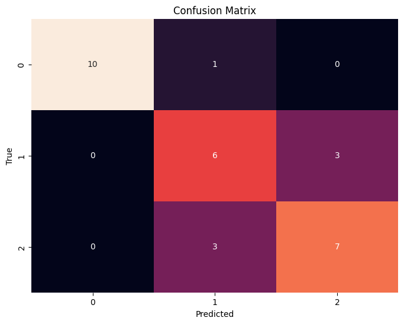

```python
# Calculate the confusion matrix
cm = confusion_matrix(y_test, y_pred)

# Create a figure for the confusion matrix heatmap
plt.figure(figsize=(8, 6))

# Use Seaborn's heatmap to create a full-color confusion matrix
sns.heatmap(cm, annot=True, fmt='d', cbar=False)

# Add labels and title
plt.xlabel('Predicted')
plt.ylabel('True')
plt.title('Confusion Matrix')

# Display the plot
plt.show()
```

## Random Forests

A Random Forest is a machine learning algorithm that builds upon the idea of decision trees but adds a layer of randomness and diversity to improve prediction accuracy and reduce overfitting. First, let's list some facts about decision trees to better understand their differences with random forests.

### Decision Tree Classifier

1. **Single Tree**: A decision tree classifier builds a single tree-like structure to make predictions.
2. **Bias and Variance**: It can have high variance, meaning it's prone to overfitting (fitting the training data too closely) and may not generalize well to new, unseen data.
3. **Feature Selection**: It selects features and thresholds based on their informativeness for each split, aiming to make the best decisions.
4. **Predictions**: New data points are classified by traversing the tree from the root to a leaf node based on their feature values.

### Random Forest Classifier

1. **Ensemble of Trees**: A random forest is an ensemble learning method that combines multiple decision trees combined into a "forest" of trees.
2. **Randomness**: It introduces randomness in two ways: by randomly selecting a subset of features for each tree and by bootstrapping (randomly sampling with replacement) the training data for each tree.
3. **Reduced Overfitting**: The randomness reduces overfitting because each tree is trained on a different subset of data and features. This diversity helps improve generalization.
4. **Voting**: For classification tasks, a random forest combines the predictions of individual trees using majority voting. For regression tasks, it averages the predictions.
5. **Predictions**: New data points are passed through each tree in the forest, and their predictions are combined to make a final prediction.

### Comparisons

- **Diversity**: A decision tree classifier is a single model, while a random forest consists of multiple decision trees. This ensemble approach introduces diversity among the trees.
- **Overfitting**: Decision trees can easily overfit, whereas random forests are less prone to overfitting due to the combination of diverse trees.
- **Accuracy**: Random forests often achieve higher accuracy on both training and validation data compared to individual decision trees.
- **Robustness**: Random forests are more robust to noisy data and outliers because they consider multiple perspectives. Complexity: Decision trees are simple to understand and visualize, while random forests are more complex due to the ensemble of trees.
- **Training Time**: Random forests may require more training time because they involve training multiple decision trees.
- In essence, a random forest is like a group of decision-making experts (the trees) who vote on the best choice. By combining their opinions, it often results in more accurate and robust predictions compared to a single decision tree.

The example below uses the same iris dataset. We provide the code for fitting and for graphing. Notice that the hyperparameter here is the number of trees in the ensemble. This is something we will select later using metrics on the validation set.

```python
# Create a Random Forest Classifier
rf_classifier = RandomForestClassifier(n_estimators=25, random_state=20)

# Fit the model to the training data
rf_classifier.fit(X_train, y_train)

# Make predictions on the validation data
y_pred = rf_classifier.predict(X_val)

# Display a classification report with precision, recall, and F1-score
report = classification_report(y_val, y_pred, target_names=data.target_names)
print("Classification Report:\n", report)
```

```
Classification Report:
               precision    recall  f1-score   support

      setosa       1.00      1.00      1.00        12
  versicolor       0.54      0.78      0.64         9
   virginica       0.60      0.33      0.43         9

    accuracy                           0.73        30
   macro avg       0.71      0.70      0.69        30
weighted avg       0.74      0.73      0.72        30
```

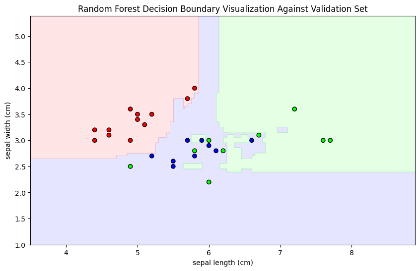

```python
# Create a meshgrid for the decision boundary plot that covers features
x_min, x_max = X_train[:, 0].min() - 1, X_train[:, 0].max() + 1
y_min, y_max = X_train[:, 1].min() - 1, X_train[:, 1].max() + 1
xx, yy = np.meshgrid(np.arange(x_min, x_max, 0.01),
                     np.arange(y_min, y_max, 0.01))

# Predict the class labels for the corresponding meshgrid points using features
mesh_points = np.c_[xx.ravel(), yy.ravel()]
Z = rf_classifier.predict(mesh_points)
Z = Z.reshape(xx.shape)

# Create a color map for the plot
cmap_background = ListedColormap(['#FFAAAA', '#AAAAFF', '#AAFFAA'])
cmap_points = ListedColormap(['#FF0000', '#0000FF', '#00FF00'])

# Plot the decision boundary
plt.figure(figsize=(10, 6))
plt.contourf(xx, yy, Z, cmap=cmap_background, alpha=0.3)
plt.scatter(X_val[:, 0], X_val[:, 1], c=y_val, cmap=cmap_points, marker='o', edgecolor='k')

# Set axis labels and title
plt.xlabel(data.feature_names[0])
plt.ylabel(data.feature_names[1])
plt.title('Random Forest Decision Boundary Visualization Against Validation Set')

plt.show()
```

Here, we consider the number of trees we can use to build a random forest model (between 1 and 125). In practice, it is common to consider much larger forests if we suspect the data has a highly complex relationship.

```python
trees = list(range(1, 125))
accuracies = []

for count in trees:
    # Create a decision tree classifier
    rfc = RandomForestClassifier(n_estimators=count, random_state=20)

    # Fit the classifier to the training data
    rfc.fit(X_train, y_train)

    # Make predictions on the validation data
    y_pred = rfc.predict(X_val)

    accuracies.append(accuracy_score(y_pred, y_val))

best_count = trees[np.argmax(accuracies)]
print(f"Best number of trees for model based on validation accuracy: {best_count}")
```

```
Best number of trees for model based on validation accuracy: 2
```

We use our optimal number of trees to construct the final model, which is evaluated against the testing set.

```python
# Create a Random Forest Classifier
rf_classifier = RandomForestClassifier(n_estimators=best_count, random_state=20)

# Fit the model to the training data
rf_classifier.fit(X_train_val, y_train_val)

# Make predictions on the validation data
y_pred = rf_classifier.predict(X_test)

# Display a classification report with precision, recall, and F1-score
report = classification_report(y_test, y_pred, target_names=data.target_names)
print("Classification Report:\n", report)
```

```
Classification Report:
               precision    recall  f1-score   support

      setosa       1.00      1.00      1.00        11
  versicolor       0.54      0.78      0.64         9
   virginica       0.67      0.40      0.50        10

    accuracy                           0.73        30
   macro avg       0.74      0.73      0.71        30
weighted avg       0.75      0.73      0.72        30
```

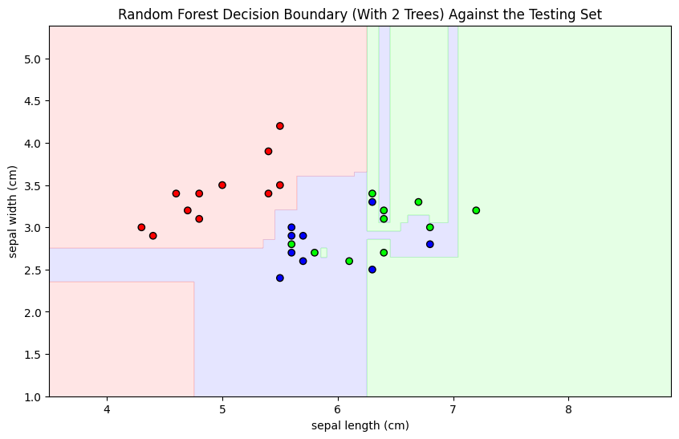

```python
# Create a meshgrid for the decision boundary plot that covers features
x_min, x_max = X_train[:, 0].min() - 1, X_train[:, 0].max() + 1
y_min, y_max = X_train[:, 1].min() - 1, X_train[:, 1].max() + 1
xx, yy = np.meshgrid(np.arange(x_min, x_max, 0.01),
                     np.arange(y_min, y_max, 0.01))

# Predict the class labels for the corresponding meshgrid points using features
mesh_points = np.c_[xx.ravel(), yy.ravel()]
Z = rf_classifier.predict(mesh_points)
Z = Z.reshape(xx.shape)

# Create a color map for the plot
cmap_background = ListedColormap(['#FFAAAA', '#AAAAFF', '#AAFFAA'])
cmap_points = ListedColormap(['#FF0000', '#0000FF', '#00FF00'])

# Plot the decision boundary
plt.figure(figsize=(10, 6))
plt.contourf(xx, yy, Z, cmap=cmap_background, alpha=0.3)
plt.scatter(X_test[:, 0], X_test[:, 1], c=y_test, cmap=cmap_points, marker='o', edgecolor='k')

# Set axis labels and title
plt.xlabel(data.feature_names[0])
plt.ylabel(data.feature_names[1])
plt.title(f'Random Forest Decision Boundary (With {best_count} Trees) Against the Testing Set')

plt.show()
```

Notice that for this example, the random forest and decision tree performed at comparable levels. In general, however, random forests will perform better. Decision trees are less complex. And as we know from studying concepts like AIC and BIC, these two elements must be balanced to avoid overfitting or underfitting.